# AE3-Copy1

### Import Data, Libraries, Clean Dataset, Convert variables to numeric for easier analysis

```python
# %%
# #
import pandas as pd
import numpy as np
from sklearn.cluster import KMeans
import matplotlib.pyplot as plt
import seaborn as sns
from sklearn.model_selection import train_test_split
from sklearn.linear_model import LinearRegression
from sklearn.ensemble import RandomForestRegressor
from sklearn.metrics import mean_squared_error, r2_score
from sklearn.metrics import accuracy_score
from sklearn.preprocessing import StandardScaler
from sklearn.tree import DecisionTreeClassifier, plot_tree #https://www.datacamp.com/tutorial/decision-tree-classification-python
import statsmodels.api as sm # https://www.statology.org/statsmodels-linear-regression-p-value/
```

```python
def preprocess_student_data(df, pass_threshold=70):
    """
    Processes/cleans student performance data with threshold for pass/fail.

    Args:
        df: Student data
        pass_threshold: Score cutoff for pass/fail (default=70)

    Returns:
        Processed DataFrame ready for modeling
    """
    # Create copy to avoid SettingWithCopyWarning
    df_clean = df.copy()

    # 1. Handle missing values
    print(f"Original shape: {df_clean.shape}")
    df_clean = df_clean.dropna()
    print(f"After dropping NA: {df_clean.shape}")

    # 2. Convert non binary categorical features
    nbc_f = {
        'Family_Income': {'Low':1, 'Medium':2, 'High':3},
        'Parental_Education_Level': {'High School':1, 'College':2, 'Postgraduate':3},
        'Parental_Involvement': {'Low':1, 'Medium':2, 'High':3},
        'Access_to_Resources': {'Low':1, 'Medium':2, 'High':3},
        'Teacher_Quality': {'Low':1, 'Medium':2, 'High':3},
        'Motivation_Level': {'Low':1, 'Medium':2, 'High':3},
        'Distance_from_Home': {'Far':1, 'Moderate':2, 'Near':3},
        'Peer_Influence': {'Negative':1, 'Neutral':2, 'Positive':3}
    }

    for col, number in nbc_f.items():
        df_clean[col] = df_clean[col].replace(number)

    # 3. Process binary categorical features
    categorical_cols = ['School_Type', 'Extracurricular_Activities',
                      'Internet_Access', 'Learning_Disabilities', 'Gender']
    df_clean[categorical_cols] = df_clean[categorical_cols].astype('category')
    df_clean = pd.get_dummies(df_clean, columns=categorical_cols, drop_first=True)

    # 4. Convert dummy columns to int
    dummy_cols = [col for col in df_clean.columns if '_' in col and col.split('_')[0] in categorical_cols]
    df_clean[dummy_cols] = df_clean[dummy_cols].astype(int)

    # 5. Add pass/fail columns
    df_clean['Pass_Fail_N'] = df_clean['Exam_Score'].apply(lambda x: 1 if x >= pass_threshold else 0)
    df_clean['Pass_Fail'] = df_clean['Exam_Score'].apply(lambda x: 'Pass' if x >= pass_threshold else 'Fail')

    return df_clean
df = pd.read_csv("StudentPerformanceFactors.csv")
df = preprocess_student_data(df)
print(df.head())
```

```
Original shape: (6607, 20)
After dropping NA: (6378, 20)
```

```
   Hours_Studied  Attendance  Parental_Involvement  Access_to_Resources  \
0             23          84                     1                    3
1             19          64                     1                    2
2             24          98                     2                    2
3             29          89                     1                    2
4             19          92                     2                    2

   Sleep_Hours  Previous_Scores  Motivation_Level  Tutoring_Sessions  \
0            7               73                 1                  0
1            8               59                 1                  2
2            7               91                 2                  2
3            8               98                 2                  1
4            6               65                 2                  3

   Family_Income  Teacher_Quality  Peer_Influence  Physical_Activity  \
```

[output cut: 26 more lines]

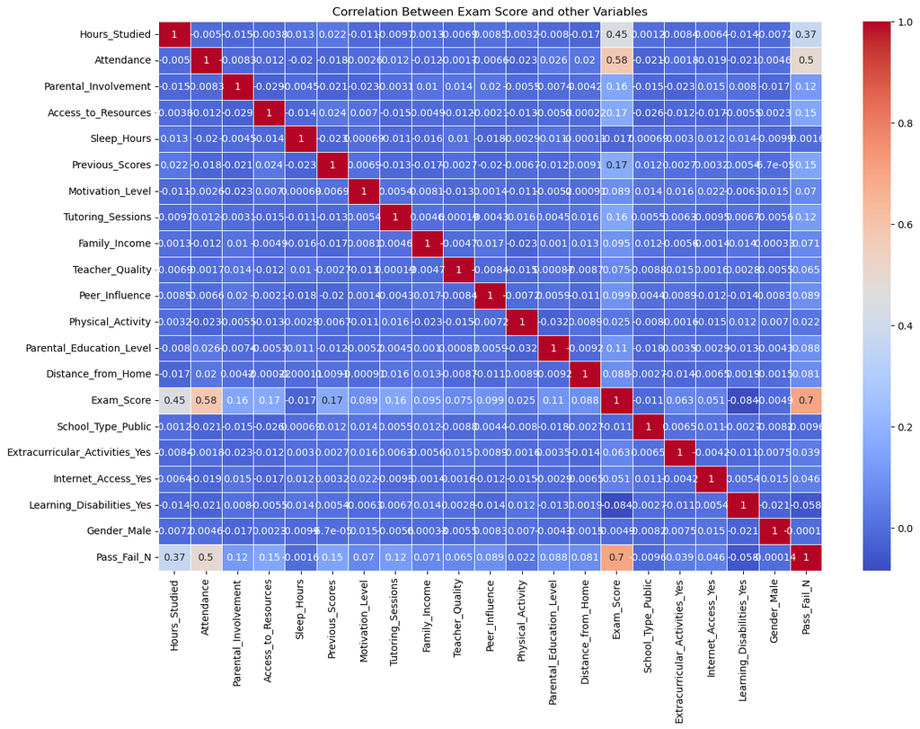

```
Correlation of Features to Exam Score (descending):
Exam_Score                        1.000000
Pass_Fail_N                       0.697625
Attendance                        0.580259
Hours_Studied                     0.445104
Previous_Scores                   0.174283
Access_to_Resources               0.167856
Tutoring_Sessions                 0.156829
Parental_Involvement              0.156014
Parental_Education_Level          0.105253
Peer_Influence                    0.099133
Family_Income                     0.094555
Motivation_Level                  0.088502
Distance_from_Home                0.088083
Teacher_Quality                   0.075107
Extracurricular_Activities_Yes    0.063063
Internet_Access_Yes               0.051124
Physical_Activity                 0.025148
Gender_Male                      -0.004932
School_Type_Public               -0.010868
Sleep_Hours                      -0.017171
Learning_Disabilities_Yes        -0.083911
Name: Exam_Score, dtype: float64
```

```python
def analyze_correlations(df):
    """
    creates heatmaps and lists correlation between exam score and columns.

    Args:df
    Returns:
        Series: Correlation values with Exam_Score, sorted descending
    """
    # Compute correlations
    corr_matrix = df.corr(numeric_only=True)
    exam_correlations = corr_matrix['Exam_Score'].sort_values(ascending=False)

    # Plot heatmap
    plt.figure(figsize=(15, 10))
    sns.heatmap(corr_matrix, annot=True, cmap="coolwarm", linewidths=0.5)
    plt.title("Correlation Between Exam Score and other Variables")
    plt.show()

    # Print sorted correlations
    print("Correlation of Features to Exam Score (descending):")
    return exam_correlations
correlations = analyze_correlations(processed_df)
print(correlations)
#what i found:the features that I had most effect was what the student was in control of: aka: attendance, hours studied, previous scores etc. but also these are continous variables so thats probably why
```

## Research Question 1: What is the best ML model to predict the final exam score? How can I improve the initial model?

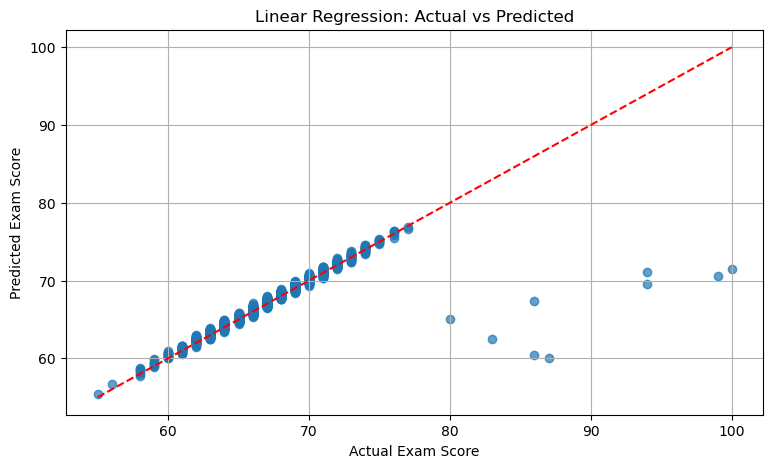

```
LINEAR Results:
 MSE: 4.153009764099104
 R²: 0.732741945510568
```

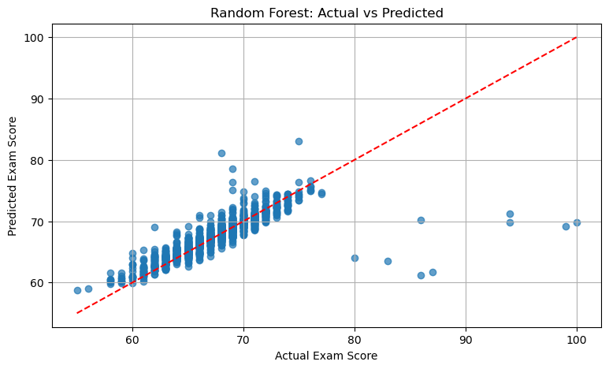

```
RANDOM_FOREST Results:
 MSE: 5.816192476489027
 R²: 0.6257113818417126
```

```python
def run_regression(df, model_type='linear', test_size=0.2, random_state=42):
    """
    Runs regression analysis on df to predict exam scores

    Args:
        df: Preprocessed DataFrame
        model_type: 'linear' or 'random_forest'
        test_size: test vs training split trial and error chosen
        Random seed (default=42) for every random seed on notebook to keep consistent

    Returns:
        model, mse, r2
    """
    # Prepare data
    X = df.drop(columns=['Exam_Score', 'Pass_Fail', 'Pass_Fail_N'])
    y = df['Exam_Score']

    # Split and scale
    X_train, X_test, y_train, y_test = train_test_split(
        X, y, test_size=test_size, random_state=random_state)
    scaler = StandardScaler()
    X_train_scaled = scaler.fit_transform(X_train)
    X_test_scaled = scaler.transform(X_test)

    # Model selection
    if model_type == 'random_forest':
        model = RandomForestRegressor(n_estimators=100, max_depth=None, random_state=random_state)
    else:
        model = LinearRegression()

    # Train and predict
    model.fit(X_train_scaled, y_train)
    y_pred = model.predict(X_test_scaled)

    # Evaluate
    mse = mean_squared_error(y_test, y_pred)
    r2 = r2_score(y_test, y_pred)

    # Plot
    plt.figure(figsize=(9, 5))
    plt.scatter(y_test, y_pred, alpha=0.7)
    plt.plot([y_test.min(), y_test.max()], [y_test.min(), y_test.max()], 'r--')
    plt.xlabel("Actual Exam Score")
    plt.ylabel("Predicted Exam Score")
    plt.title(f"{'Random Forest' if model_type == 'random_forest' else 'Linear Regression'}: Actual vs Predicted")
    plt.grid(True)
    plt.show()

    # Print results
    print(f"\n{model_type.upper()} Results:")
    print(f" MSE: {mse}")
    print(f" R²: {r2}")

    return model, mse, r2,
linear_model, linear_mse, linear_r2, = run_regression(df, model_type='linear')


rf_model, rf_mse, rf_r2, = run_regression(df, model_type='random_forest')

#for parameters such as test size, I just played around until I got the highest result
```

# Decision Tree

# Create Decision Tree classifer object

# note: this was a mistake, trying to predict Exam score with a classifier because its trying to predict a label, not a value so accuracy score was naturally very low. Next I made a pass fail column for a classifier wth a threshold of 70 so i could use the decision tree classifier

X = df.drop(columns=['Exam_Score', 'Pass_Fail', 'Pass_Fail_N']) #Features (everything except 'Exam score') y = df['Exam_Score']  
X_train, X_test, y_train, y_test = train_test_split(X, y, test_size=0.2, random_state=42)

# Train Decision Tree Classifer

clf = clf.fit(X_train,y_train)

# Predict the response for test dataset

y_pred = clf.predict(X_test)

print("Accuracy:",metrics.accuracy_score(y_test, y_pred))

# first accuracy score was Accuracy: 0.2115987460815047, maybe ill drop the really not important features and do it again

# Get feature importances

# weak_features = feature_importance[feature_importance['Importance'] < 0.01]['Feature']

# Drop weak features

# X_train_reduced = X_train.drop(columns=weak_features)

# X_test_reduced = X_test.drop(columns=weak_features)

# Retrain

# clf_reduced = DecisionTreeClassifier(random_state=42)

# clf_reduced.fit(X_train_reduced, y_train)

# y_pred_reduced = clf_reduced.predict(X_test_reduced)

# print("Accuracy after dropping weak features:", accuracy_score(y_test, y_pred_reduced))

# did not work actually made it slightly worse

# Note I realized that decision trees are better for classification because exam scores arent continuous and they end at 100 so its better to use pass fail